# Week 1 - Practice

C.A. Kiahtipes

8/30/2023

## Week 1 Practice: Drawing With Vectors

### 1.1 Introduction

This set of exercises is meant to help you practice some of the concepts we learned in week 1. Your challenge at the end of class was to make a line drawing, extrapolate vectors of x, y coordinates from it, and then plot it in R.

#### Don’t be afriad to draw it!

Pencil and paper are great coding tools. Sketch your ideas, draw diagrams, and try to set some expectations for what you might see. Using any sort of ruled paper, you can map out plotting decisions and think about how to organize your data to fit within the plot’s dimensions.

### 1.2 Draw a Square

Let’s start with some basic shapes and then ramp up the complexity. What you are supposed to see here is that vectors are counts, measurements, and coordinates alike. We can store, call, and plot this data in a lot of different ways. Let’s see the basic process in action.

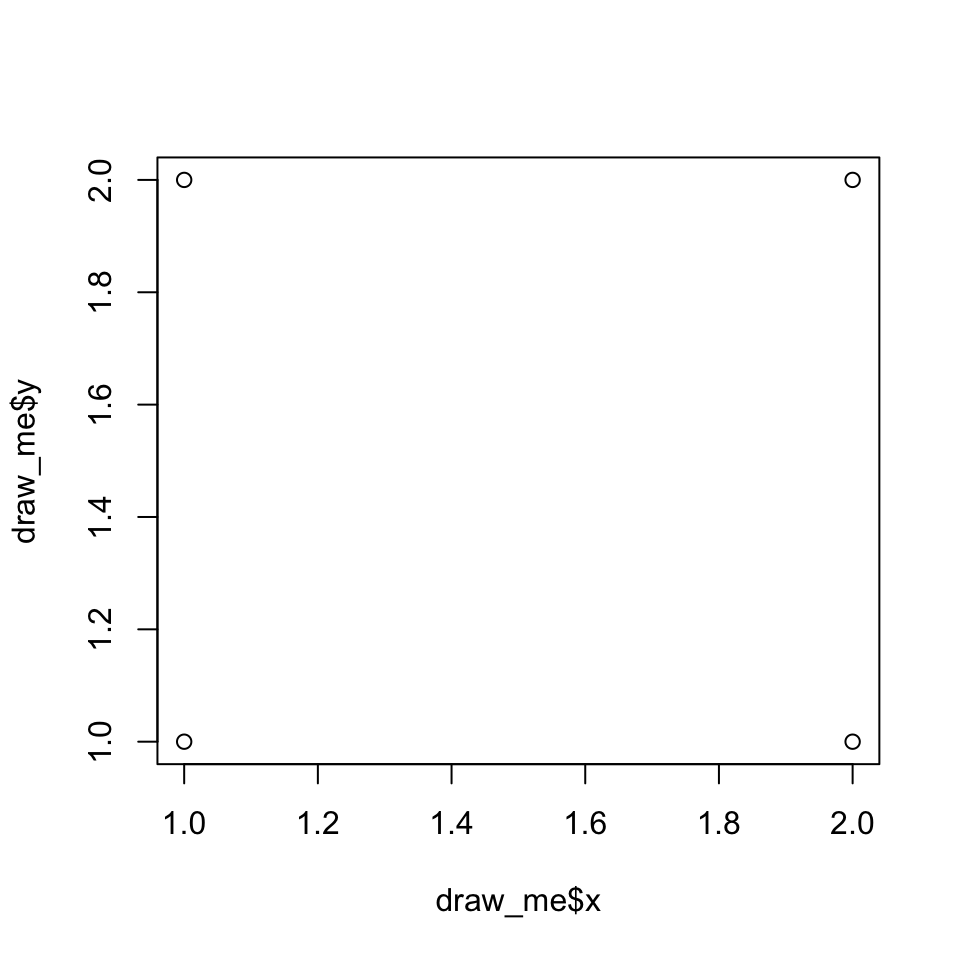

```r
draw_me <- list(x = c(1, 1, 2, 2), y = c(1, 2, 2, 1)) #We're just putting our two vectors into a list here.

plot(draw_me)
```

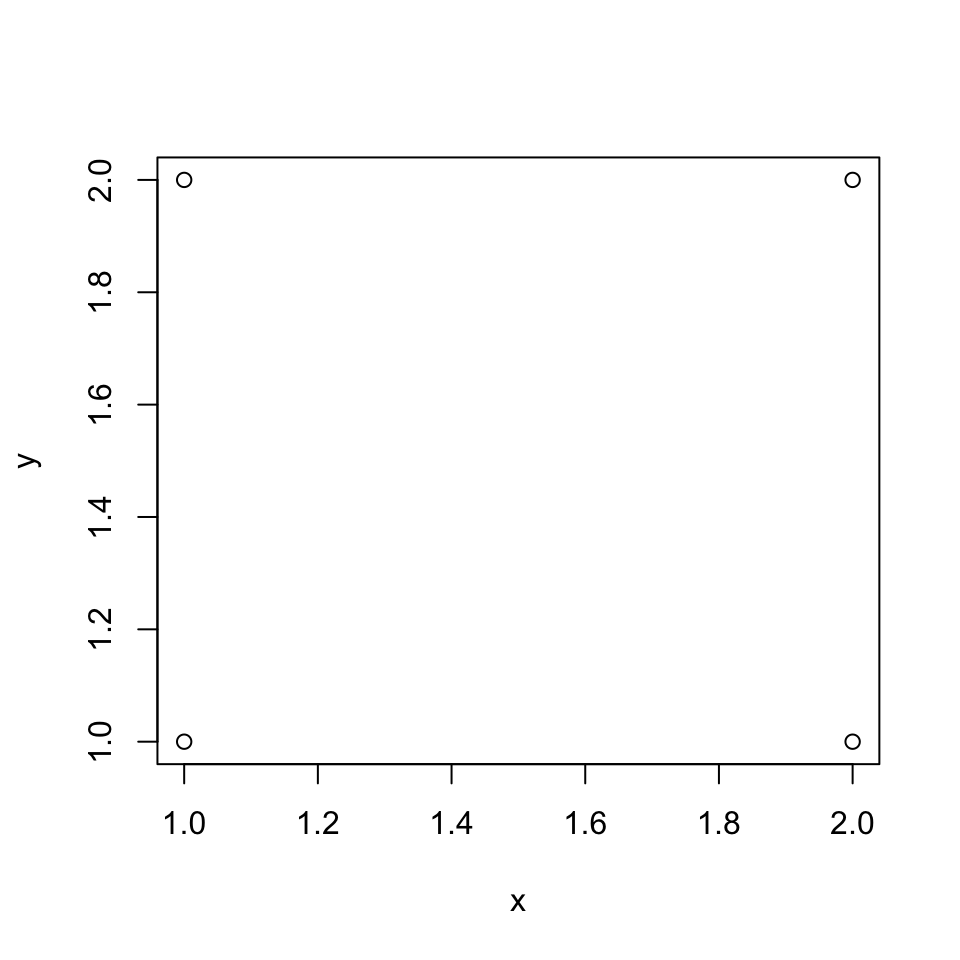

```r
#Can be more verbose...

x = c(1, 1, 2, 2)
y = c(1, 2, 2, 1)

plot(x, y)
```

Since we’re drawing shapes, we’re going to set the plot type argument to line plot (type = “l”).

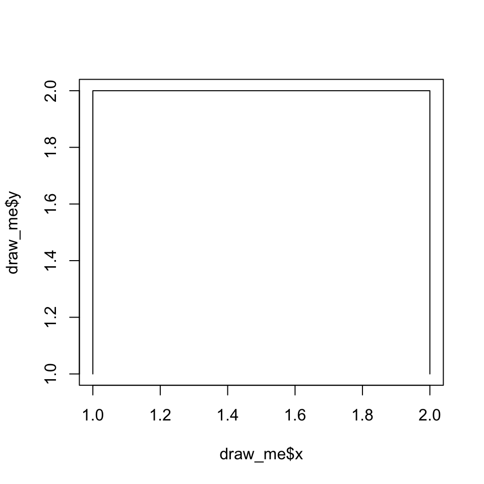

```r
plot(draw_me,
     type = "l")
```

Our square isn’t complete! It’s also hard to appreciate its squareness because of the framing of the plot (R always cuts it as close as possible to the outside of the object). If we want to make the lines connect, we need to come back to the starting location again, so we need 5 positions to draw our square.

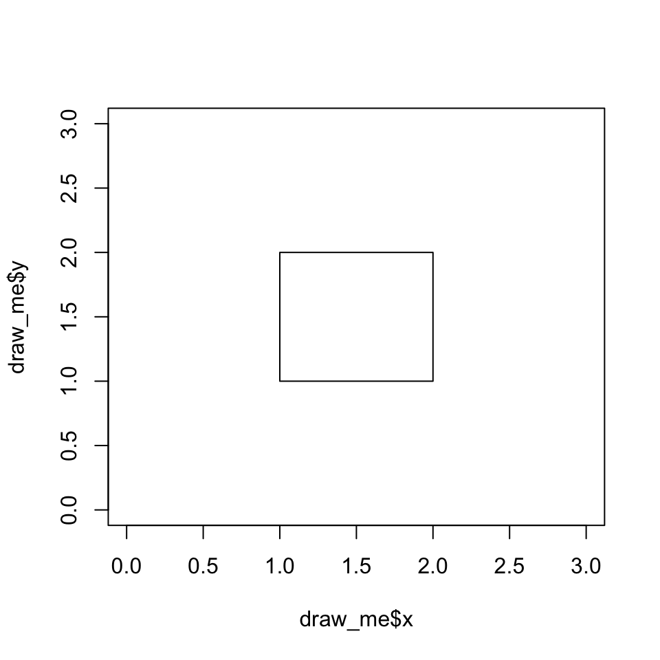

```r
draw_me <- list(x = c(1, 1, 2, 2, 1),
                y = c(1, 2, 2, 1, 1)) #We're just putting our two vectors into a list here.


plot(draw_me,
     type = "l",
     xlim = c(0,3), #Adding plotting arguments "xlim =" and "ylim =", which allow us to define the plot window.
     ylim = c(0,3))
```

### 1.3 Drawing Hexagons and Octagons

Drawing some shapes from our imagination is easy enough. We can also do a hexagon using 7 digits. Below, we also label the points with the text() function. This function works with plot() and allows us to add text to the plot window. For this function, we need to feed it x and y coordinates as well as a string of labels.

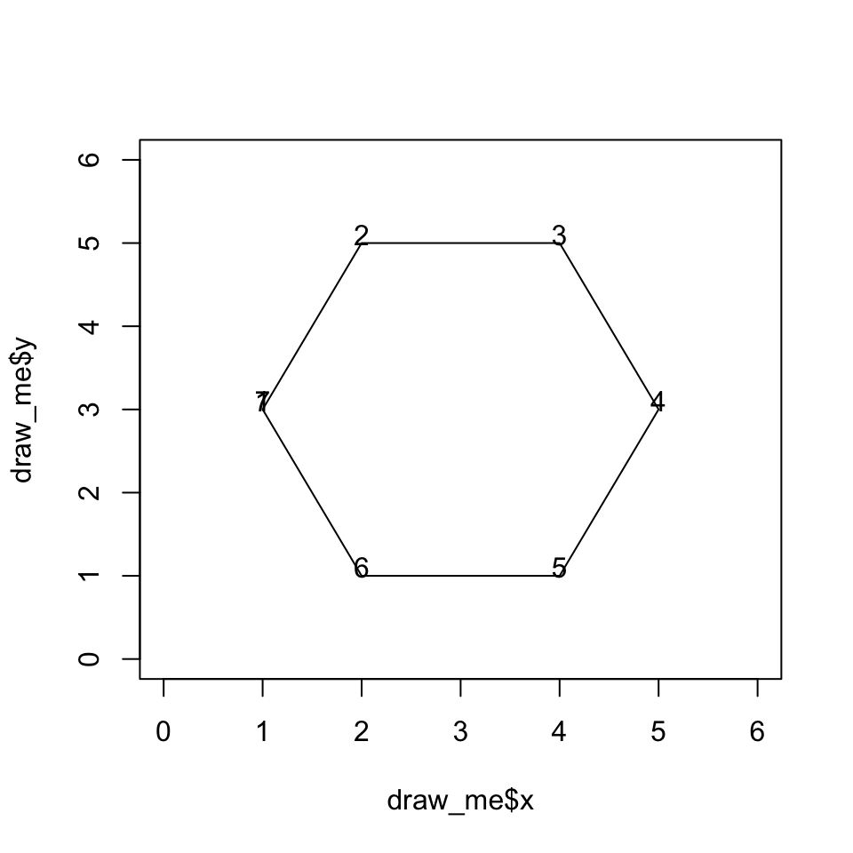

```r
draw_me <- list(x = c(1, 2, 4, 5, 4, 2, 1),
                y = c(2, 4, 4, 2, 0, 0, 2)+1)

plot(draw_me,
     type = "l",
     xlim = c(0,6),
     ylim = c(0,6))

text(draw_me$x, #We are using text() here. We give it the same x coordinates as the drawing.
     draw_me$y+0.1, #We give it the same y coordinates, but add a constant so the numbers sit just above the line segments.
     labels = 1:7) #We add an integer label up to 7.
```

And octagons with 9 digits.

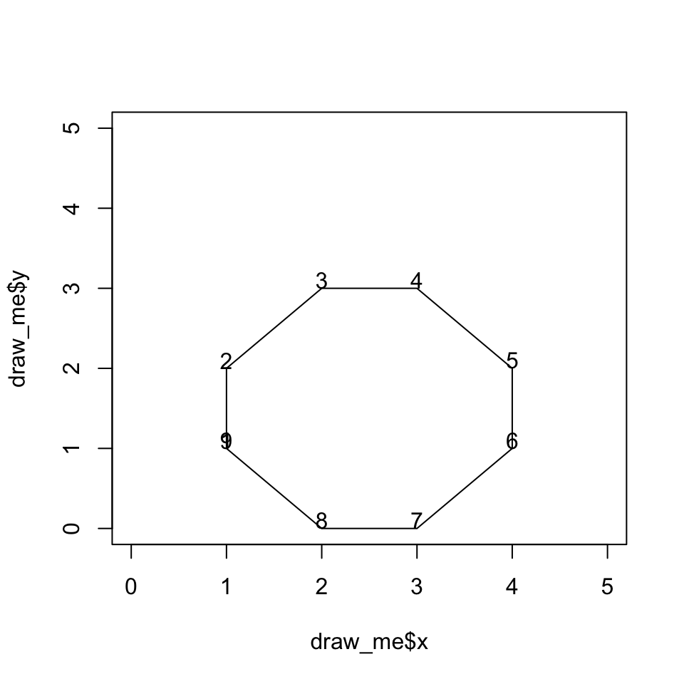

```r
draw_me <- list(x = c(1, 1, 2, 3, 4, 4, 3, 2, 1),
                y = c(1, 2, 3, 3, 2, 1, 0, 0, 1))

plot(draw_me,
     type = "l",
     xlim = c(0,5),
     ylim = c(0,5))

text(draw_me$x,
     draw_me$y+0.1,
     labels = 1:length(draw_me$x))
```

### 1.4 Designing Vectors with Pen and Paper

Using a pad and paper, we can map out the outline of a star. I’m including a picture from my phone as well as a sketch of my work below with plot().

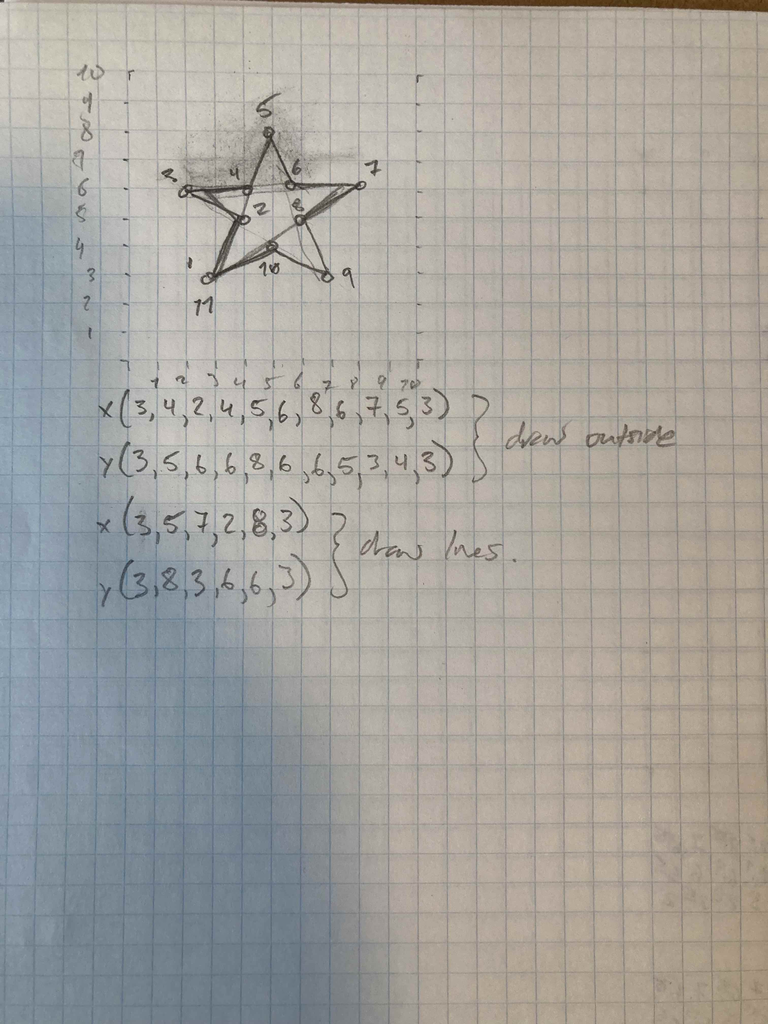

[figure not shown]

```r
knitr::include_graphics("images/star.jpg")
```

So, we take each numbered point and use this to fill in the position in our variables (x and y).

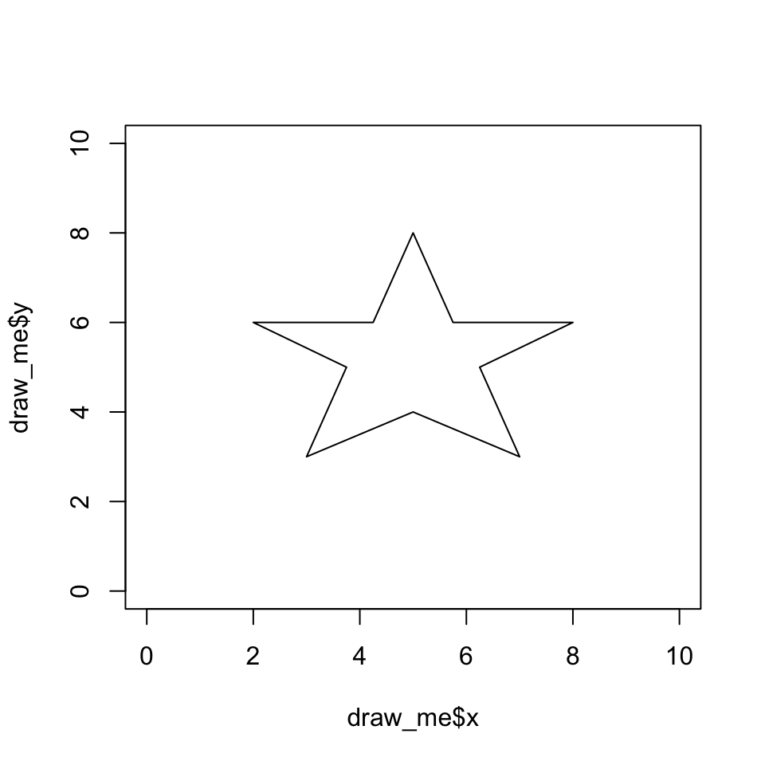

```r
draw_me = list(x = c(3, 3.75, 2, 4.25, 5, 5.75, 8, 6.25, 7, 5, 3),
               y = c(3, 5, 6, 6, 8, 6, 6, 5, 3, 4, 3))

plot(draw_me,
     type = "l",
     xlim = c(0,10),
     ylim = c(0,10))
```

Although it won’t look the same, we can draw a star in the same way that we learn to by hand, through connecting five dots.

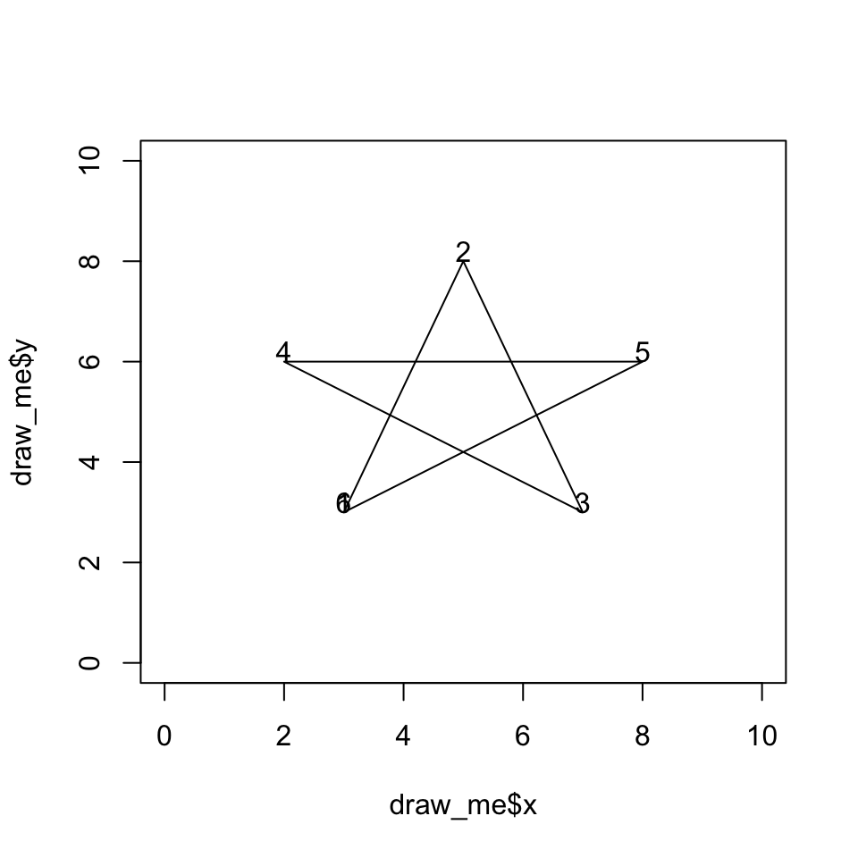

```r
draw_me = list(x = c(3, 5, 7, 2, 8, 3),
               y = c(3, 8, 3, 6, 6, 3))

plot(draw_me,
     type = "l",
     xlim = c(0,10),
     ylim = c(0,10))

text(draw_me$x,
     draw_me$y+0.2,
     labels = 1:length(draw_me$x))
```

### 1.5 Drawing A Dinosaur

Last, we can attempt something a bit more complicated. I drew a very rough-looking dinosaur, made some points to plot, recorded their locations, and then put together a plot.

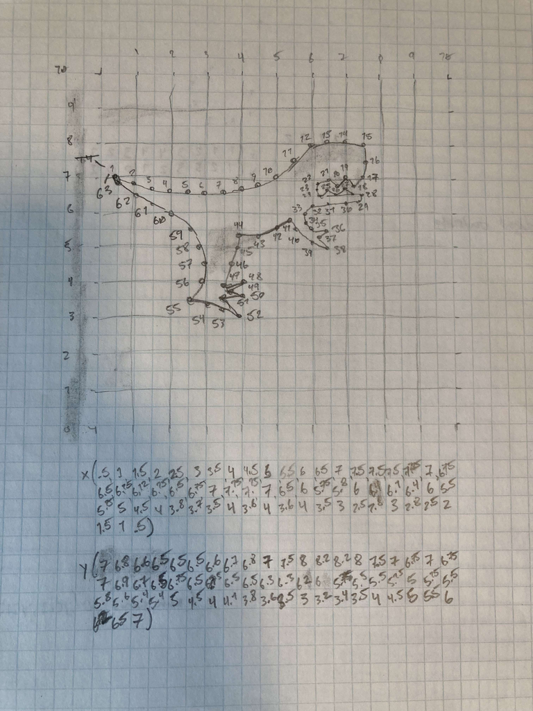

```r
knitr::include_graphics("images/dino.jpg")
```

And we execute this all below. Notice the way the code is written for the “draw_me” list object. I used <shift+enter> to break up my lines into strings of 20 digits, which helped me keep track during data entry. I also broke up the “x = …..” and the “y = …..” strings with <shift+enter>. This adds non-coding break in your text and moves it to the next line. This helps write clearer code.

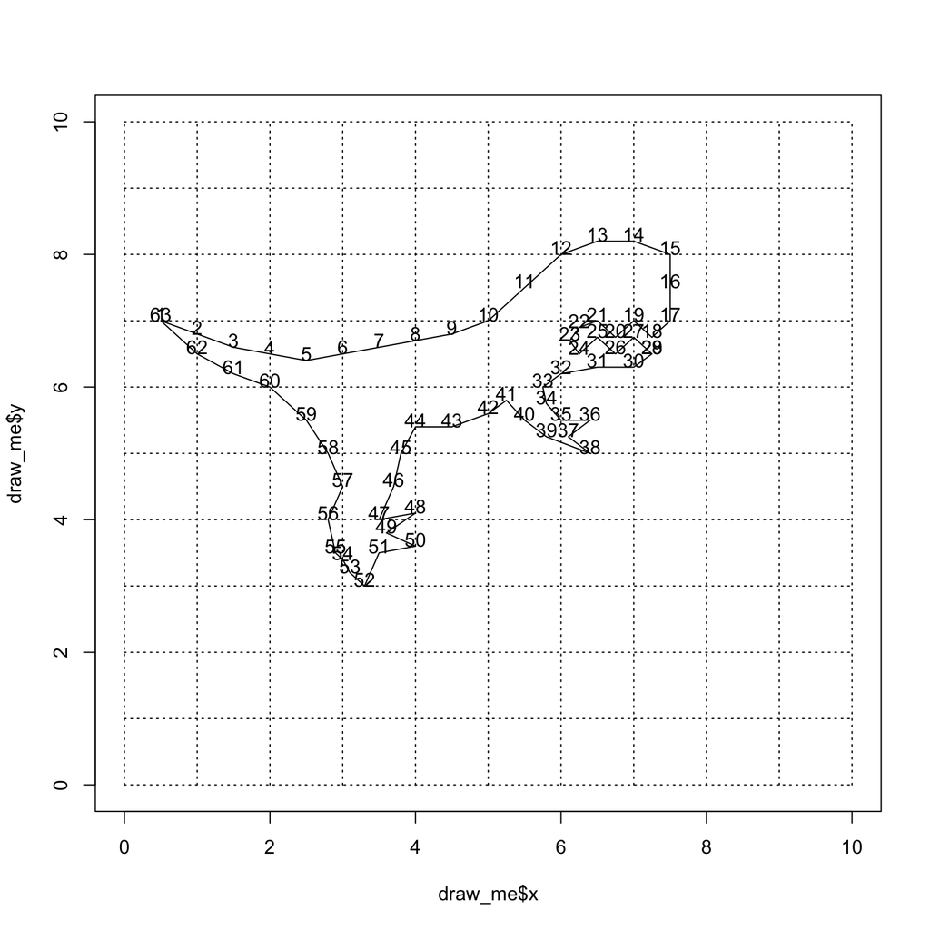

```r
draw_me = list(x = c(0.5, 1, 1.5, 2, 2.5, 3, 3.5, 4, 4.5, 5, 5.5, 6, 6.5, 7, 7.5, 7.5, 7.5, 7.25, 7, 6.75, #We open the list() function here...
       6.5, 6.25, 6.12, 6.25, 6.5, 6.75, 7, 7.25, 7.25, 7, 6.5, 6, 5.75, 5.8, 6, 6.4, 6.1, 6.4, 5.8, 5.5,
       5.25, 5, 4.5, 4, 3.8, 3.7, 3.5, 4, 3.6, 4, 3.5, 3.3, 3.1, 3, 2.9, 2.8, 3, 2.8, 2.5, 2,
       1.5, 1, 0.5), #Note that we end with a comma here because we have to enter the y object still...

              y = c(7, 6.8, 6.6, 6.5, 6.4, 6.5, 6.6, 6.7, 6.8, 7, 7.5, 8, 8.2, 8.2, 8, 7.5, 7, 6.75, 7, 6.75,
       7, 6.9, 6.7, 6.5, 6.75, 6.5, 6.75, 6.5, 6.5, 6.3, 6.3, 6.2, 6, 5.75, 5.5, 5.5, 5.25, 5, 5.25, 5.5,
       5.8, 5.6, 5.4, 5.4, 5, 4.5, 4, 4.1, 3.8, 3.6, 3.5, 3, 3.2, 3.4, 3.5, 4, 4.5, 5, 5.5, 6,
       6.2, 6.5, 7)) #Here we add the last parentheses to close out the list function call above.


plot(draw_me,
     type = "l",
     xlim = c(0,10),
     ylim = c(0,10))

text(draw_me$x, draw_me$y+0.1, c(1:length(draw_me$y)))

draw_grid(0:10, 0:10) #Calling a custom function here to draw a grid in the background.
```

### 1.6 Your Turn!

Experiment with these methods and come up with some line art of your own. It need not be terribly complicated, but show that you can use these methods to draw something.